# Risk Factor Analysis

## Outcome Variable

**Outcome Variable:** wasted

## Predictor Variables

**Intervention Variable:** hhwealth_quart

**Adjustment Set:**

- arm
- sex
- W_mage
- meducyrs
- feducyrs
- W_gagebrth
- W_birthwt
- W_birthlen
- W_nchldlt5
- W_parity
- delta_W_mage
- delta_meducyrs
- delta_feducyrs
- delta_W_gagebrth
- delta_W_birthwt
- delta_W_birthlen
- delta_W_nchldlt5
- delta_W_parity

## Stratifying Variables

The analysis was stratified on these variable(s):

- agecat
- studyid
- country

## Data Summary

| agecat | studyid | country | hhwealth_quart | wasted | n_cell | n |
| --- | --- | --- | --- | --- | --- | --- |
| Birth | ki0047075b-MAL-ED | BANGLADESH | Wealth Q4 | 0 | 19 | 76 |
| Birth | ki0047075b-MAL-ED | BANGLADESH | Wealth Q4 | 1 | 2 | 76 |
| Birth | ki0047075b-MAL-ED | BANGLADESH | Wealth Q1 | 0 | 12 | 76 |
| Birth | ki0047075b-MAL-ED | BANGLADESH | Wealth Q1 | 1 | 5 | 76 |
| Birth | ki0047075b-MAL-ED | BANGLADESH | Wealth Q2 | 0 | 14 | 76 |
| Birth | ki0047075b-MAL-ED | BANGLADESH | Wealth Q2 | 1 | 4 | 76 |
| Birth | ki0047075b-MAL-ED | BANGLADESH | Wealth Q3 | 0 | 19 | 76 |
| Birth | ki0047075b-MAL-ED | BANGLADESH | Wealth Q3 | 1 | 1 | 76 |
| Birth | ki0047075b-MAL-ED | INDIA | Wealth Q4 | 0 | 8 | 54 |
| Birth | ki0047075b-MAL-ED | INDIA | Wealth Q4 | 1 | 3 | 54 |
| Birth | ki0047075b-MAL-ED | INDIA | Wealth Q1 | 0 | 11 | 54 |
| Birth | ki0047075b-MAL-ED | INDIA | Wealth Q1 | 1 | 6 | 54 |
| Birth | ki0047075b-MAL-ED | INDIA | Wealth Q2 | 0 | 12 | 54 |
| Birth | ki0047075b-MAL-ED | INDIA | Wealth Q2 | 1 | 3 | 54 |
| Birth | ki0047075b-MAL-ED | INDIA | Wealth Q3 | 0 | 9 | 54 |
| Birth | ki0047075b-MAL-ED | INDIA | Wealth Q3 | 1 | 2 | 54 |
| Birth | ki0047075b-MAL-ED | NEPAL | Wealth Q4 | 0 | 9 | 30 |
| Birth | ki0047075b-MAL-ED | NEPAL | Wealth Q4 | 1 | 0 | 30 |
| Birth | ki0047075b-MAL-ED | NEPAL | Wealth Q1 | 0 | 7 | 30 |
| Birth | ki0047075b-MAL-ED | NEPAL | Wealth Q1 | 1 | 1 | 30 |
| Birth | ki0047075b-MAL-ED | NEPAL | Wealth Q2 | 0 | 5 | 30 |
| Birth | ki0047075b-MAL-ED | NEPAL | Wealth Q2 | 1 | 1 | 30 |
| Birth | ki0047075b-MAL-ED | NEPAL | Wealth Q3 | 0 | 5 | 30 |
| Birth | ki0047075b-MAL-ED | NEPAL | Wealth Q3 | 1 | 2 | 30 |
| Birth | ki0047075b-MAL-ED | PERU | Wealth Q4 | 0 | 10 | 36 |
| Birth | ki0047075b-MAL-ED | PERU | Wealth Q4 | 1 | 0 | 36 |
| Birth | ki0047075b-MAL-ED | PERU | Wealth Q1 | 0 | 8 | 36 |
| Birth | ki0047075b-MAL-ED | PERU | Wealth Q1 | 1 | 1 | 36 |
| Birth | ki0047075b-MAL-ED | PERU | Wealth Q2 | 0 | 9 | 36 |
| Birth | ki0047075b-MAL-ED | PERU | Wealth Q2 | 1 | 0 | 36 |

[output cut: 346 more lines]

The following strata were considered:

- agecat: 24 months, studyid: ki0047075b-MAL-ED, country: BANGLADESH
- agecat: 24 months, studyid: ki0047075b-MAL-ED, country: INDIA
- agecat: 24 months, studyid: ki0047075b-MAL-ED, country: NEPAL
- agecat: 24 months, studyid: ki0047075b-MAL-ED, country: PERU
- agecat: 24 months, studyid: ki0047075b-MAL-ED, country: SOUTH AFRICA
- agecat: 24 months, studyid: ki0047075b-MAL-ED, country: TANZANIA, UNITED REPUBLIC OF
- agecat: 24 months, studyid: ki1000108-CMC-V-BCS-2002, country: INDIA
- agecat: 24 months, studyid: ki1000108-IRC, country: INDIA
- agecat: 24 months, studyid: ki1017093b-PROVIDE, country: BANGLADESH
- agecat: 24 months, studyid: ki1066203-TanzaniaChild2, country: TANZANIA, UNITED REPUBLIC OF
- agecat: 24 months, studyid: ki1113344-GMS-Nepal, country: NEPAL
- agecat: 24 months, studyid: ki1114097-CONTENT, country: PERU
- agecat: 24 months, studyid: ki1135781-COHORTS, country: GUATEMALA
- agecat: 24 months, studyid: ki1135781-COHORTS, country: PHILIPPINES
- agecat: 24 months, studyid: ki1148112-LCNI-5, country: MALAWI
- agecat: 24 months, studyid: kiGH5241-JiVitA-3, country: BANGLADESH
- agecat: 24 months, studyid: kiGH5241-JiVitA-4, country: BANGLADESH
- agecat: 6 months, studyid: ki0047075b-MAL-ED, country: BANGLADESH
- agecat: 6 months, studyid: ki0047075b-MAL-ED, country: INDIA
- agecat: 6 months, studyid: ki0047075b-MAL-ED, country: NEPAL
- agecat: 6 months, studyid: ki0047075b-MAL-ED, country: PERU
- agecat: 6 months, studyid: ki0047075b-MAL-ED, country: SOUTH AFRICA
- agecat: 6 months, studyid: ki0047075b-MAL-ED, country: TANZANIA, UNITED REPUBLIC OF
- agecat: 6 months, studyid: ki1000108-CMC-V-BCS-2002, country: INDIA
- agecat: 6 months, studyid: ki1000108-IRC, country: INDIA
- agecat: 6 months, studyid: ki1017093b-PROVIDE, country: BANGLADESH
- agecat: 6 months, studyid: ki1066203-TanzaniaChild2, country: TANZANIA, UNITED REPUBLIC OF
- agecat: 6 months, studyid: ki1113344-GMS-Nepal, country: NEPAL
- agecat: 6 months, studyid: ki1114097-CONTENT, country: PERU
- agecat: 6 months, studyid: ki1135781-COHORTS, country: GUATEMALA
- agecat: 6 months, studyid: ki1135781-COHORTS, country: PHILIPPINES
- agecat: 6 months, studyid: ki1148112-LCNI-5, country: MALAWI
- agecat: 6 months, studyid: kiGH5241-JiVitA-3, country: BANGLADESH
- agecat: 6 months, studyid: kiGH5241-JiVitA-4, country: BANGLADESH
- agecat: Birth, studyid: ki0047075b-MAL-ED, country: BANGLADESH
- agecat: Birth, studyid: ki0047075b-MAL-ED, country: INDIA
- agecat: Birth, studyid: ki0047075b-MAL-ED, country: NEPAL
- agecat: Birth, studyid: ki0047075b-MAL-ED, country: PERU
- agecat: Birth, studyid: ki0047075b-MAL-ED, country: SOUTH AFRICA
- agecat: Birth, studyid: ki0047075b-MAL-ED, country: TANZANIA, UNITED REPUBLIC OF
- agecat: Birth, studyid: ki1000108-CMC-V-BCS-2002, country: INDIA
- agecat: Birth, studyid: ki1000108-IRC, country: INDIA
- agecat: Birth, studyid: ki1114097-CONTENT, country: PERU
- agecat: Birth, studyid: ki1135781-COHORTS, country: GUATEMALA
- agecat: Birth, studyid: ki1135781-COHORTS, country: PHILIPPINES
- agecat: Birth, studyid: kiGH5241-JiVitA-3, country: BANGLADESH
- agecat: Birth, studyid: kiGH5241-JiVitA-4, country: BANGLADESH

### Dropped Strata

Some strata were dropped due to rare outcomes:

- agecat: Birth, studyid: ki0047075b-MAL-ED, country: BANGLADESH
- agecat: Birth, studyid: ki0047075b-MAL-ED, country: INDIA
- agecat: Birth, studyid: ki0047075b-MAL-ED, country: NEPAL
- agecat: Birth, studyid: ki0047075b-MAL-ED, country: PERU
- agecat: Birth, studyid: ki0047075b-MAL-ED, country: SOUTH AFRICA
- agecat: Birth, studyid: ki0047075b-MAL-ED, country: TANZANIA, UNITED REPUBLIC OF
- agecat: Birth, studyid: ki1000108-CMC-V-BCS-2002, country: INDIA
- agecat: Birth, studyid: ki1114097-CONTENT, country: PERU
- agecat: 6 months, studyid: ki0047075b-MAL-ED, country: BANGLADESH
- agecat: 6 months, studyid: ki0047075b-MAL-ED, country: INDIA
- agecat: 6 months, studyid: ki0047075b-MAL-ED, country: NEPAL
- agecat: 6 months, studyid: ki0047075b-MAL-ED, country: PERU
- agecat: 6 months, studyid: ki0047075b-MAL-ED, country: SOUTH AFRICA
- agecat: 6 months, studyid: ki0047075b-MAL-ED, country: TANZANIA, UNITED REPUBLIC OF
- agecat: 6 months, studyid: ki1114097-CONTENT, country: PERU
- agecat: 6 months, studyid: ki1148112-LCNI-5, country: MALAWI
- agecat: 24 months, studyid: ki0047075b-MAL-ED, country: BANGLADESH
- agecat: 24 months, studyid: ki0047075b-MAL-ED, country: INDIA
- agecat: 24 months, studyid: ki0047075b-MAL-ED, country: NEPAL
- agecat: 24 months, studyid: ki0047075b-MAL-ED, country: PERU
- agecat: 24 months, studyid: ki0047075b-MAL-ED, country: SOUTH AFRICA
- agecat: 24 months, studyid: ki0047075b-MAL-ED, country: TANZANIA, UNITED REPUBLIC OF
- agecat: 24 months, studyid: ki1000108-CMC-V-BCS-2002, country: INDIA
- agecat: 24 months, studyid: ki1066203-TanzaniaChild2, country: TANZANIA, UNITED REPUBLIC OF
- agecat: 24 months, studyid: ki1114097-CONTENT, country: PERU
- agecat: 24 months, studyid: ki1148112-LCNI-5, country: MALAWI

## Methods Detail

We’re interested in the causal parameters $E[Y_a]$ for all values of $a \in \mathcal{A}$. These parameters represent the mean outcome if, possibly contrary to fact, we intervened to set all units to have $A=a$. Under the randomization and positivity assumptions, these are identified by the statistical parameters $\psi_a=E_W[E_{Y|A,W}(Y|A=a,W)]$. In addition, we’re interested in the mean of $Y$, $E[Y]$ under no intervention (the observed mean). We will estimate these parameters by using SuperLearner to fit the relevant likelihood factors – $E_{Y|A,W}(Y|A=a,W)$ and $p(A=a|W)$, and then updating our likelihood fit using a joint TMLE.

For unadjusted analyses ($W=\{\}$), initial likelihoods were estimated using Lrnr_glm to estimate the simple $E(Y|A)$ and Lrnr_mean to estimate $p(A)$. For adjusted analyses, a small library containing Lrnr_glmnet, Lrnr_xgboost, and Lrnr_mean was used.

Having estimated these parameters, we will then use the delta method to estimate relative risks and attributable risks relative to a prespecified baseline level of $A$.

# Results Detail

## Results Plots

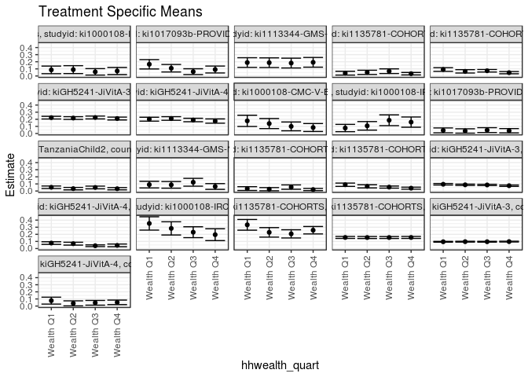

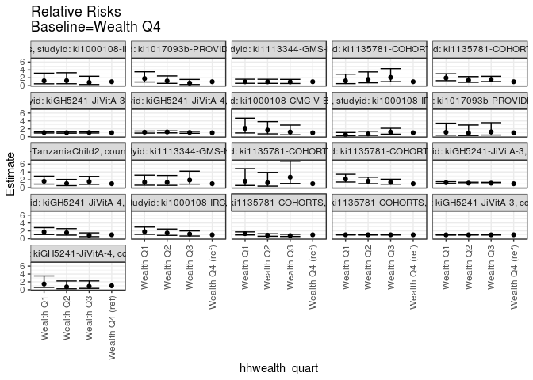

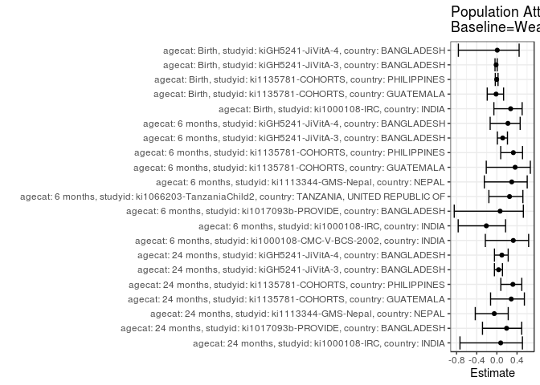

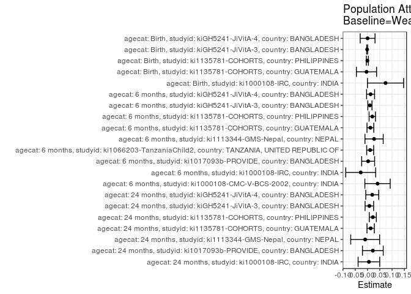

## Results Table

### Parameter: TSM

| agecat | studyid | country | intervention_level | baseline_level | estimate | ci_lower | ci_upper |
| --- | --- | --- | --- | --- | --- | --- | --- |
| Birth | ki1000108-IRC | INDIA | Wealth Q4 | NA | 0.1947617 | 0.1114458 | 0.2780775 |
| Birth | ki1000108-IRC | INDIA | Wealth Q1 | NA | 0.3530539 | 0.2592351 | 0.4468726 |
| Birth | ki1000108-IRC | INDIA | Wealth Q2 | NA | 0.2834027 | 0.1903476 | 0.3764578 |
| Birth | ki1000108-IRC | INDIA | Wealth Q3 | NA | 0.2298481 | 0.1533990 | 0.3062971 |
| Birth | ki1135781-COHORTS | GUATEMALA | Wealth Q4 | NA | 0.2578092 | 0.2058027 | 0.3098158 |
| Birth | ki1135781-COHORTS | GUATEMALA | Wealth Q1 | NA | 0.3337571 | 0.2583686 | 0.4091456 |
| Birth | ki1135781-COHORTS | GUATEMALA | Wealth Q2 | NA | 0.2275669 | 0.1608209 | 0.2943130 |
| Birth | ki1135781-COHORTS | GUATEMALA | Wealth Q3 | NA | 0.2065620 | 0.1489345 | 0.2641894 |
| Birth | ki1135781-COHORTS | PHILIPPINES | Wealth Q4 | NA | 0.1561629 | 0.1422016 | 0.1701242 |
| Birth | ki1135781-COHORTS | PHILIPPINES | Wealth Q1 | NA | 0.1561410 | 0.1422230 | 0.1700591 |
| Birth | ki1135781-COHORTS | PHILIPPINES | Wealth Q2 | NA | 0.1551373 | 0.1410439 | 0.1692307 |
| Birth | ki1135781-COHORTS | PHILIPPINES | Wealth Q3 | NA | 0.1552258 | 0.1415564 | 0.1688952 |
| Birth | kiGH5241-JiVitA-3 | BANGLADESH | Wealth Q4 | NA | 0.0973733 | 0.0918654 | 0.1028812 |
| Birth | kiGH5241-JiVitA-3 | BANGLADESH | Wealth Q1 | NA | 0.0952441 | 0.0894671 | 0.1010210 |
| Birth | kiGH5241-JiVitA-3 | BANGLADESH | Wealth Q2 | NA | 0.0964974 | 0.0909865 | 0.1020083 |
| Birth | kiGH5241-JiVitA-3 | BANGLADESH | Wealth Q3 | NA | 0.0956222 | 0.0901193 | 0.1011251 |
| Birth | kiGH5241-JiVitA-4 | BANGLADESH | Wealth Q4 | NA | 0.0522876 | 0.0206412 | 0.0839340 |
| Birth | kiGH5241-JiVitA-4 | BANGLADESH | Wealth Q1 | NA | 0.0760234 | 0.0274510 | 0.1245958 |
| Birth | kiGH5241-JiVitA-4 | BANGLADESH | Wealth Q2 | NA | 0.0378378 | 0.0022240 | 0.0734516 |
| Birth | kiGH5241-JiVitA-4 | BANGLADESH | Wealth Q3 | NA | 0.0459770 | 0.0128344 | 0.0791197 |
| 6 months | ki1000108-CMC-V-BCS-2002 | INDIA | Wealth Q4 | NA | 0.0842105 | 0.0282917 | 0.1401294 |
| 6 months | ki1000108-CMC-V-BCS-2002 | INDIA | Wealth Q1 | NA | 0.1777778 | 0.0986824 | 0.2568731 |
| 6 months | ki1000108-CMC-V-BCS-2002 | INDIA | Wealth Q2 | NA | 0.1397849 | 0.0692131 | 0.2103567 |
| 6 months | ki1000108-CMC-V-BCS-2002 | INDIA | Wealth Q3 | NA | 0.1000000 | 0.0379361 | 0.1620639 |
| 6 months | ki1000108-IRC | INDIA | Wealth Q4 | NA | 0.1600000 | 0.0880583 | 0.2319417 |
| 6 months | ki1000108-IRC | INDIA | Wealth Q1 | NA | 0.0769231 | 0.0256474 | 0.1281988 |
| 6 months | ki1000108-IRC | INDIA | Wealth Q2 | NA | 0.1078431 | 0.0475736 | 0.1681127 |
| 6 months | ki1000108-IRC | INDIA | Wealth Q3 | NA | 0.1862745 | 0.1106267 | 0.2619224 |
| 6 months | ki1017093b-PROVIDE | BANGLADESH | Wealth Q4 | NA | 0.0387097 | 0.0083152 | 0.0691041 |
| 6 months | ki1017093b-PROVIDE | BANGLADESH | Wealth Q1 | NA | 0.0437956 | 0.0094988 | 0.0780924 |

[output cut: 54 more lines]

### Parameter: E(Y)

| agecat | studyid | country | intervention_level | baseline_level | estimate | ci_lower | ci_upper |
| --- | --- | --- | --- | --- | --- | --- | --- |
| Birth | ki1000108-IRC | INDIA | NA | NA | 0.2682216 | 0.2212677 | 0.3151755 |
| Birth | ki1135781-COHORTS | GUATEMALA | NA | NA | 0.2537723 | 0.2221611 | 0.2853834 |
| Birth | ki1135781-COHORTS | PHILIPPINES | NA | NA | 0.1556246 | 0.1424244 | 0.1688248 |
| Birth | kiGH5241-JiVitA-3 | BANGLADESH | NA | NA | 0.0959786 | 0.0907764 | 0.1011808 |
| Birth | kiGH5241-JiVitA-4 | BANGLADESH | NA | NA | 0.0527086 | 0.0336587 | 0.0717585 |
| 6 months | ki1000108-CMC-V-BCS-2002 | INDIA | NA | NA | 0.1250000 | 0.0911644 | 0.1588356 |
| 6 months | ki1000108-IRC | INDIA | NA | NA | 0.1323529 | 0.0994307 | 0.1652752 |
| 6 months | ki1017093b-PROVIDE | BANGLADESH | NA | NA | 0.0413793 | 0.0251566 | 0.0576020 |
| 6 months | ki1066203-TanzaniaChild2 | TANZANIA, UNITED REPUBLIC OF | NA | NA | 0.0430906 | 0.0342310 | 0.0519502 |
| 6 months | ki1113344-GMS-Nepal | NEPAL | NA | NA | 0.0905861 | 0.0668565 | 0.1143158 |
| 6 months | ki1135781-COHORTS | GUATEMALA | NA | NA | 0.0323974 | 0.0209875 | 0.0438073 |
| 6 months | ki1135781-COHORTS | PHILIPPINES | NA | NA | 0.0594974 | 0.0505830 | 0.0684118 |
| 6 months | kiGH5241-JiVitA-3 | BANGLADESH | NA | NA | 0.0845851 | 0.0797798 | 0.0893904 |
| 6 months | kiGH5241-JiVitA-4 | BANGLADESH | NA | NA | 0.0569712 | 0.0481278 | 0.0658146 |
| 24 months | ki1000108-IRC | INDIA | NA | NA | 0.0757946 | 0.0501131 | 0.1014762 |
| 24 months | ki1017093b-PROVIDE | BANGLADESH | NA | NA | 0.1126516 | 0.0868319 | 0.1384714 |
| 24 months | ki1113344-GMS-Nepal | NEPAL | NA | NA | 0.1827309 | 0.1487560 | 0.2167058 |
| 24 months | ki1135781-COHORTS | GUATEMALA | NA | NA | 0.0449331 | 0.0323731 | 0.0574931 |
| 24 months | ki1135781-COHORTS | PHILIPPINES | NA | NA | 0.0681911 | 0.0582056 | 0.0781766 |
| 24 months | kiGH5241-JiVitA-3 | BANGLADESH | NA | NA | 0.2180591 | 0.2081778 | 0.2279404 |
| 24 months | kiGH5241-JiVitA-4 | BANGLADESH | NA | NA | 0.1945032 | 0.1812962 | 0.2077102 |

### Parameter: RR

| agecat | studyid | country | intervention_level | baseline_level | estimate | ci_lower | ci_upper |
| --- | --- | --- | --- | --- | --- | --- | --- |
| Birth | ki1000108-IRC | INDIA | Wealth Q4 | Wealth Q4 | 1.0000000 | 1.0000000 | 1.000000 |
| Birth | ki1000108-IRC | INDIA | Wealth Q1 | Wealth Q4 | 1.8127482 | 1.1092268 | 2.962474 |
| Birth | ki1000108-IRC | INDIA | Wealth Q2 | Wealth Q4 | 1.4551258 | 0.8591783 | 2.464437 |
| Birth | ki1000108-IRC | INDIA | Wealth Q3 | Wealth Q4 | 1.1801504 | 0.6990598 | 1.992326 |
| Birth | ki1135781-COHORTS | GUATEMALA | Wealth Q4 | Wealth Q4 | 1.0000000 | 1.0000000 | 1.000000 |
| Birth | ki1135781-COHORTS | GUATEMALA | Wealth Q1 | Wealth Q4 | 1.2945892 | 0.9592584 | 1.747143 |
| Birth | ki1135781-COHORTS | GUATEMALA | Wealth Q2 | Wealth Q4 | 0.8826950 | 0.6212039 | 1.254259 |
| Birth | ki1135781-COHORTS | GUATEMALA | Wealth Q3 | Wealth Q4 | 0.8012202 | 0.5702342 | 1.125772 |
| Birth | ki1135781-COHORTS | PHILIPPINES | Wealth Q4 | Wealth Q4 | 1.0000000 | 1.0000000 | 1.000000 |
| Birth | ki1135781-COHORTS | PHILIPPINES | Wealth Q1 | Wealth Q4 | 0.9998600 | 0.9557663 | 1.045988 |
| Birth | ki1135781-COHORTS | PHILIPPINES | Wealth Q2 | Wealth Q4 | 0.9934323 | 0.9462550 | 1.042962 |
| Birth | ki1135781-COHORTS | PHILIPPINES | Wealth Q3 | Wealth Q4 | 0.9939993 | 0.9507415 | 1.039225 |
| Birth | kiGH5241-JiVitA-3 | BANGLADESH | Wealth Q4 | Wealth Q4 | 1.0000000 | 1.0000000 | 1.000000 |
| Birth | kiGH5241-JiVitA-3 | BANGLADESH | Wealth Q1 | Wealth Q4 | 0.9781332 | 0.9453760 | 1.012025 |
| Birth | kiGH5241-JiVitA-3 | BANGLADESH | Wealth Q2 | Wealth Q4 | 0.9910044 | 0.9584508 | 1.024664 |
| Birth | kiGH5241-JiVitA-3 | BANGLADESH | Wealth Q3 | Wealth Q4 | 0.9820166 | 0.9489803 | 1.016203 |
| Birth | kiGH5241-JiVitA-4 | BANGLADESH | Wealth Q4 | Wealth Q4 | 1.0000000 | 1.0000000 | 1.000000 |
| Birth | kiGH5241-JiVitA-4 | BANGLADESH | Wealth Q1 | Wealth Q4 | 1.4539474 | 0.6034264 | 3.503266 |
| Birth | kiGH5241-JiVitA-4 | BANGLADESH | Wealth Q2 | Wealth Q4 | 0.7236486 | 0.2358403 | 2.220432 |
| Birth | kiGH5241-JiVitA-4 | BANGLADESH | Wealth Q3 | Wealth Q4 | 0.8793103 | 0.3464580 | 2.231690 |
| 6 months | ki1000108-CMC-V-BCS-2002 | INDIA | Wealth Q4 | Wealth Q4 | 1.0000000 | 1.0000000 | 1.000000 |
| 6 months | ki1000108-CMC-V-BCS-2002 | INDIA | Wealth Q1 | Wealth Q4 | 2.1111111 | 0.9492417 | 4.695106 |
| 6 months | ki1000108-CMC-V-BCS-2002 | INDIA | Wealth Q2 | Wealth Q4 | 1.6599462 | 0.7208115 | 3.822666 |
| 6 months | ki1000108-CMC-V-BCS-2002 | INDIA | Wealth Q3 | Wealth Q4 | 1.1875000 | 0.4785137 | 2.946950 |
| 6 months | ki1000108-IRC | INDIA | Wealth Q4 | Wealth Q4 | 1.0000000 | 1.0000000 | 1.000000 |
| 6 months | ki1000108-IRC | INDIA | Wealth Q1 | Wealth Q4 | 0.4807692 | 0.2151491 | 1.074321 |
| 6 months | ki1000108-IRC | INDIA | Wealth Q2 | Wealth Q4 | 0.6740196 | 0.3289721 | 1.380976 |
| 6 months | ki1000108-IRC | INDIA | Wealth Q3 | Wealth Q4 | 1.1642157 | 0.6351858 | 2.133861 |
| 6 months | ki1017093b-PROVIDE | BANGLADESH | Wealth Q4 | Wealth Q4 | 1.0000000 | 1.0000000 | 1.000000 |
| 6 months | ki1017093b-PROVIDE | BANGLADESH | Wealth Q1 | Wealth Q4 | 1.1313869 | 0.3732482 | 3.429451 |

[output cut: 54 more lines]

### Parameter: PAR

| agecat | studyid | country | intervention_level | baseline_level | estimate | ci_lower | ci_upper |
| --- | --- | --- | --- | --- | --- | --- | --- |
| Birth | ki1000108-IRC | INDIA | Wealth Q4 | NA | 0.0734599 | -0.0001772 | 0.1470970 |
| Birth | ki1135781-COHORTS | GUATEMALA | Wealth Q4 | NA | -0.0040370 | -0.0451080 | 0.0370341 |
| Birth | ki1135781-COHORTS | PHILIPPINES | Wealth Q4 | NA | -0.0005383 | -0.0047858 | 0.0037091 |
| Birth | kiGH5241-JiVitA-3 | BANGLADESH | Wealth Q4 | NA | -0.0013947 | -0.0034724 | 0.0006830 |
| Birth | kiGH5241-JiVitA-4 | BANGLADESH | Wealth Q4 | NA | 0.0004211 | -0.0297010 | 0.0305431 |
| 6 months | ki1000108-CMC-V-BCS-2002 | INDIA | Wealth Q4 | NA | 0.0407895 | -0.0107598 | 0.0923387 |
| 6 months | ki1000108-IRC | INDIA | Wealth Q4 | NA | -0.0276471 | -0.0886587 | 0.0333646 |
| 6 months | ki1017093b-PROVIDE | BANGLADESH | Wealth Q4 | NA | 0.0026696 | -0.0236597 | 0.0289989 |
| 6 months | ki1066203-TanzaniaChild2 | TANZANIA, UNITED REPUBLIC OF | Wealth Q4 | NA | 0.0108533 | -0.0033950 | 0.0251017 |
| 6 months | ki1113344-GMS-Nepal | NEPAL | Wealth Q4 | NA | 0.0267564 | -0.0103529 | 0.0638656 |
| 6 months | ki1135781-COHORTS | GUATEMALA | Wealth Q4 | NA | 0.0117484 | -0.0020944 | 0.0255913 |
| 6 months | ki1135781-COHORTS | PHILIPPINES | Wealth Q4 | NA | 0.0194714 | 0.0064805 | 0.0324623 |
| 6 months | kiGH5241-JiVitA-3 | BANGLADESH | Wealth Q4 | NA | 0.0098208 | 0.0013818 | 0.0182598 |
| 6 months | kiGH5241-JiVitA-4 | BANGLADESH | Wealth Q4 | NA | 0.0125131 | -0.0038166 | 0.0288428 |
| 24 months | ki1000108-IRC | INDIA | Wealth Q4 | NA | 0.0057946 | -0.0382574 | 0.0498467 |
| 24 months | ki1017093b-PROVIDE | BANGLADESH | Wealth Q4 | NA | 0.0217729 | -0.0204504 | 0.0639963 |
| 24 months | ki1113344-GMS-Nepal | NEPAL | Wealth Q4 | NA | -0.0094500 | -0.0682848 | 0.0493848 |
| 24 months | ki1135781-COHORTS | GUATEMALA | Wealth Q4 | NA | 0.0128343 | -0.0021425 | 0.0278111 |
| 24 months | ki1135781-COHORTS | PHILIPPINES | Wealth Q4 | NA | 0.0216815 | 0.0073626 | 0.0360004 |
| 24 months | kiGH5241-JiVitA-3 | BANGLADESH | Wealth Q4 | NA | 0.0075991 | -0.0097631 | 0.0249614 |
| 24 months | kiGH5241-JiVitA-4 | BANGLADESH | Wealth Q4 | NA | 0.0192825 | -0.0070099 | 0.0455749 |

### Parameter: PAF

| agecat | studyid | country | intervention_level | baseline_level | estimate | ci_lower | ci_upper |
| --- | --- | --- | --- | --- | --- | --- | --- |
| Birth | ki1000108-IRC | INDIA | Wealth Q4 | NA | 0.2738777 | -0.0589416 | 0.5020938 |
| Birth | ki1135781-COHORTS | GUATEMALA | Wealth Q4 | NA | -0.0159078 | -0.1913516 | 0.1336994 |
| Birth | ki1135781-COHORTS | PHILIPPINES | Wealth Q4 | NA | -0.0034592 | -0.0311212 | 0.0234607 |
| Birth | kiGH5241-JiVitA-3 | BANGLADESH | Wealth Q4 | NA | -0.0145318 | -0.0364653 | 0.0069375 |
| Birth | kiGH5241-JiVitA-4 | BANGLADESH | Wealth Q4 | NA | 0.0079884 | -0.7636551 | 0.4420184 |
| 6 months | ki1000108-CMC-V-BCS-2002 | INDIA | Wealth Q4 | NA | 0.3263158 | -0.2283944 | 0.6305336 |
| 6 months | ki1000108-IRC | INDIA | Wealth Q4 | NA | -0.2088889 | -0.7673694 | 0.1731144 |
| 6 months | ki1017093b-PROVIDE | BANGLADESH | Wealth Q4 | NA | 0.0645161 | -0.8459385 | 0.5259159 |
| 6 months | ki1066203-TanzaniaChild2 | TANZANIA, UNITED REPUBLIC OF | Wealth Q4 | NA | 0.2518715 | -0.1580840 | 0.5167050 |
| 6 months | ki1113344-GMS-Nepal | NEPAL | Wealth Q4 | NA | 0.2953692 | -0.2489631 | 0.6024666 |
| 6 months | ki1135781-COHORTS | GUATEMALA | Wealth Q4 | NA | 0.3626352 | -0.2100558 | 0.6642850 |
| 6 months | ki1135781-COHORTS | PHILIPPINES | Wealth Q4 | NA | 0.3272648 | 0.0768626 | 0.5097451 |
| 6 months | kiGH5241-JiVitA-3 | BANGLADESH | Wealth Q4 | NA | 0.1161055 | 0.0103578 | 0.2105535 |
| 6 months | kiGH5241-JiVitA-4 | BANGLADESH | Wealth Q4 | NA | 0.2196390 | -0.1326783 | 0.4623687 |
| 24 months | ki1000108-IRC | INDIA | Wealth Q4 | NA | 0.0764516 | -0.7319580 | 0.5075275 |
| 24 months | ki1017093b-PROVIDE | BANGLADESH | Wealth Q4 | NA | 0.1932767 | -0.2850373 | 0.4935536 |
| 24 months | ki1113344-GMS-Nepal | NEPAL | Wealth Q4 | NA | -0.0517155 | -0.4284281 | 0.2256485 |
| 24 months | ki1135781-COHORTS | GUATEMALA | Wealth Q4 | NA | 0.2856317 | -0.1247612 | 0.5462841 |
| 24 months | ki1135781-COHORTS | PHILIPPINES | Wealth Q4 | NA | 0.3179524 | 0.0792529 | 0.4947701 |
| 24 months | kiGH5241-JiVitA-3 | BANGLADESH | Wealth Q4 | NA | 0.0348489 | -0.0481613 | 0.1112850 |
| 24 months | kiGH5241-JiVitA-4 | BANGLADESH | Wealth Q4 | NA | 0.0991372 | -0.0472460 | 0.2250590 |